# COVID-19 trends by CCG level

Thibaut Jombart, Dirk Schumacher

2020-09-14

Using the new algorithm ASMODEE (**A**utomatic **S**election of **M**odels and **O**utlier **D**etection for **E**pidemics) we monitor changes in potential COVID-19 cases reported through the [NHS pathways](https://digital.nhs.uk/dashboards/nhs-pathways), including calls to 111, 999, and 111-online. These analyses are broken down by Clinical Commissioning Groups [(CCG)](https://www.england.nhs.uk/ccgs/). Only the last 6 weeks of data are used. The last week of data is not used to define the temporal trend so that recent outliers can be detected.

**Note**: this research has not been peer-reviewed yet. This website is still experimental. Please contact the authors before using its content.

Models considered here for trend fitting include:

- linear regression of counts over time
- Poisson GLM with a constant rate
- Negative Binomial GLM with a log-linear effect of time
- Negative Binomial GLM with a log-linear effect of time and a ‘weekday’ effect distinguishing weekends, Mondays, and the rest of the week

Analyses are run separately for each CCG.

## Results: 111/999 calls

Recent observations suggest that 111/999 calls may be more reflective of actual dynamics than 111-online. Therefore, this section only shows analyses based on these data. See next section for results using the whole dataset, i.e. including 111/999 calls and 111-online.

### Top 25 CCG

These plots show the 25 CGGs with the most increases in the last 7 days. Future versions will provide plots for all CCGs.

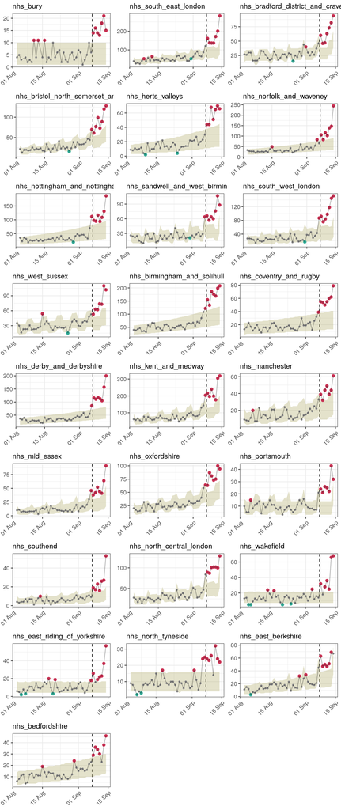

### Table summary for all CCGs

| ccg | p_value | k | n_outliers_recent | n_outliers | n_recent_increase |
| --- | --- | --- | --- | --- | --- |
| nhs_bury | 3.80e-06 | 7 | 7 | 10 | 7 |
| nhs_south_east_london | 6.31e-06 | 7 | 7 | 10 | 7 |
| nhs_bradford_district_and_craven | 4.08e-05 | 7 | 7 | 9 | 7 |
| nhs_bristol_north_somerset_and_south_gloucestershire | 4.08e-05 | 7 | 7 | 9 | 7 |
| nhs_herts_valleys | 4.08e-05 | 7 | 7 | 9 | 7 |
| nhs_norfolk_and_waveney | 4.08e-05 | 7 | 7 | 9 | 7 |
| nhs_nottingham_and_nottinghamshire | 4.08e-05 | 7 | 7 | 9 | 7 |
| nhs_sandwell_and_west_birmingham | 4.08e-05 | 7 | 7 | 9 | 7 |
| nhs_south_west_london | 4.08e-05 | 7 | 7 | 9 | 7 |
| nhs_west_sussex | 4.08e-05 | 7 | 7 | 9 | 7 |

[output cut: 126 more lines]

## Results: 111/999 calls and 111-online

These results reproduce the analyses above using all data, i.e. also including 111-online calls.

### Top 25 CCG

These plots show the 25 CGGs with the most increases in the last 7 days. Future versions will provide plots for all CCGs.

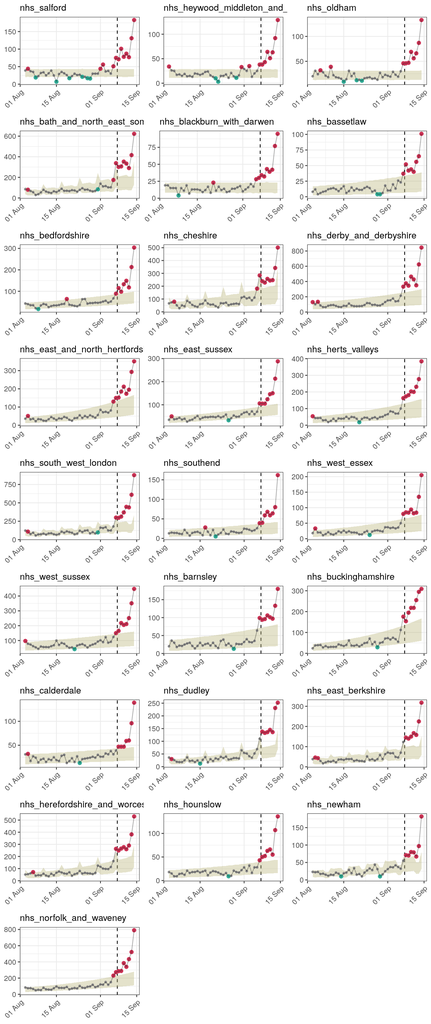

### Table summary for all CCGs

| ccg | p_value | k | n_outliers_recent | n_outliers | n_recent_increase |
| --- | --- | --- | --- | --- | --- |
| nhs_salford | 4.76e-14 | 7 | 7 | 18 | 7 |
| nhs_heywood_middleton_and_rochdale | 1.21e-09 | 7 | 7 | 14 | 7 |
| nhs_oldham | 1.20e-08 | 7 | 7 | 13 | 7 |
| nhs_bath_and_north_east_somerset_swindon_and_wiltshire | 8.71e-07 | 7 | 7 | 11 | 7 |
| nhs_blackburn_with_darwen | 8.71e-07 | 7 | 7 | 11 | 7 |
| nhs_bassetlaw | 6.31e-06 | 7 | 7 | 10 | 7 |
| nhs_bedfordshire | 6.31e-06 | 7 | 7 | 10 | 7 |
| nhs_cheshire | 6.31e-06 | 7 | 7 | 10 | 7 |
| nhs_derby_and_derbyshire | 6.31e-06 | 7 | 7 | 10 | 7 |
| nhs_east_and_north_hertfordshire | 6.31e-06 | 7 | 7 | 10 | 7 |

[output cut: 126 more lines]